# SU_25_River_Rockfish_Proj_Ambient_V0.1

River Mckegney

2025-07-17

## Setup, and Packages

Code Packages:

```r
# Load packages
library(gridExtra) # For using grid.table to save tables as images
library(flextable) # Alternative method to save df as image
library(tidyverse)
library(zoo)
library(lme4)
library(lmerTest)
library(rlang)
library(nortest) # For ad.test
library(car) # For homogeneity of variance with leveneTest
library(rcompanion) # For scheirerRayHare test
library(pastecs) # For stat.desc
library(ggpubr) # For assumption plots
library(conover.test) # For the conover.Iman() test function
library(DescTools) # Contain alternative ConoverTest function
library(rstatix) # tidyverse adapted stat tests and mshapiro_test() functions
library(DHARMa) # For multi-level lm models and shapiro test
library(patchwork) # For combining ggplots
```

## Intro:

River Mckegney’s CSUMB UROC Innovation Scholars Summer 2025 Research Project. This Research project is about gopher rockfish (*S. Carnatus*) and their physiological response to environmental exposure of low pH and dissolved oxygen, factors mimicking the synergistic effects of ocean acidification and Hypoxic (OAH) climate change stressors. The effects of OAH on *S. carnatus* reproduction will also be investigated.

Gopher Rockfish (*S. carnatus*) are viviparous species, where pregnant females develop often multiple larvae internally, and give live birth during spawing season. Mothers brood in the spring (Jan-May) that coincides with a seasonal upwelling period (Apr-Jun) along the Pacific Northwest, which is known to cause environmental changes to near shore water chemistry involving a decrease in pH (more acidic) and dissolved oxygen concentrations [DO]. These changes may act as synergistic stressors, effecting *S. carnatus* physiology and reproduction. If conditions are not favorable, or energetic demands are too costly, then pregnant *S. carnatus* may reabsorb their eggs and the pregnancy aborted, a process known as atresia.

This study will investigate how *S. carnatus* blood work parameters compare between patients exposed to ambient and OAH treatments (~ treatment groups), and will also look for differences between female gopher rockfish who experience atresia and those who undergo parturition or successful pregnancy (parturition status groups), as well as comparing the two treatments and parturition status groups.

## Award Credits:

This project was funded by the undergraduate CSU-COAST and Jim and Peggy Ryan Marine Science Research Award Program. This project is in association with California State University Monterey Bay UROC Innovation Scholars Summer 2025 Research Program.

## Hypotheses:

The hypotheses of this study are listed below:

Template: 1). response to OAH stress compared to ambient treatment: 2). response to atresia compared to successful parturition: 3). response towards OAH & atresia conditions vs ambient & successful parturition:

**Internal pH**

pH response to OAH stress compared to ambient treatment: Healthy pregnant gopher rockfish are hypothesized to maintain their internal blood pH. Acclimitization to a new stabilized pH setpoint is also possible. Changes to internal pH could indicate compromised metabolic function. Natural change to pH due to pregnancy, and other reproduction related confounding variables could also be considered.

pH response to atresia compared to successful parturition:

pH response towards OAH & atresia conditions vs ambient & successful parturition:

**Glucose**

Glucose response to OAH stress compared to ambient treatment: Internal glucose is expected to increase in response to OAH treatment, as a physiological stress response to the supposed increased environmental stress.

Glucose response to atresia compared to successful parturition: Internal glucose is expected to be greater for *S. carnatus* that experience atresia compared to those who have successful parturition. This is reaction is suspected as a stress response towards metabolic demands of egg reabsorption, and suspected high energetic demands of metabolism (indicated by atresia) stimulating immune response.

Glucose response towards OAH & atresia conditions vs ambient & successful parturition: It is unknown how *S. carnatus* blood glucose levels will compare between individuals who experience OAH treatment and atresia versus those who are exposed to ambient treatment and have successful parturition.

**Hematocrit**

Hematocrit response to OAH stress compared to ambient treatment: The OAH treatment is hypothesized to increase percent hematocrit, as a physiological response to counter low environmental dissolved oxygen concentrations [DO], and meet adequate blood oxygen metabolic demands.

Hematocrit response to atresia compared to successful parturition: Atresia patients are hypothesized to have decreased hematocrit levels in contrast to sucessful parturition *S. carnatus* individuals, because pregnancy (larvae development) is suspected to increase the blood gas demands of maternal individuals, and thus require a boost in gas exchange efficiency.

Hematocrit response towards OAH & successful parturition conditions vs ambient & atresia: Individuals exposed to OAH treatment and have a sucessful pregnancy are hypothesized to have higher hematocrit levels compared to atresia patients in the ambient treatment tank.

**Ions: Sodium, Chloride, Potassium, and Calcium**

**Sodium: Na+**

Sodium response to OAH stress compared to ambient treatment: I suspect internal blood sodium concentrations to increase in response to OAH stress. This is suspected due to the previous studies on acid secretion and NA+ absorption proposed mechanisms (Evans et al. 2005).

Sodium response to atresia compared to successful parturition: This depends on how pregnancy effects natural acid-base and osmoregulatory ion balance. Furthure investigation would be required to assess this potentially confounding idea.

Sodium response towards OAH & atresia conditions vs ambient & successful parturition: The interactive role of parturition and decreased environmental pH & oxygen concentrations on gopher rockfish blood sodium concentration is unknown. Due to a lack of study on the effects of parturition on ion balance it is difficult to predict how this might influence pH change variables. This experiment however could produce useful data in assessing this concept.

**Potassium: K+**

Potassium response to OAH stress compared to ambient treatment: A decrease in potassium levels in response to OAH treatment is hypothesized, due to the stressor inducing mild metabolic acidosis, causing a bulk movement of potassium from intracellular to extracellular spaces, where it may be excreted via diffusion through gills or skin, or lost in fecal waste.

Potassium response to atresia compared to successful parturition:

Potassium response towards OAH & atresia conditions vs ambient & successful parturition:

**Chloride: Cl-**

Chloride response to OAH stress compared to ambient treatment:

Chloride response to atresia compared to successful parturition:

Chloride response towards OAH & atresia conditions vs ambient & successful parturition:

**Calcium: Ca+2**

Calcium response to OAH stress compared to ambient treatment:

Calcium response to atresia compared to successful parturition:

Calcium response towards OAH & atresia conditions vs ambient & successful parturition:

## Data Entry: Read-in data

```r
# Read and call data into df

# Primary samples df
ABL90 <- read.csv("Raw_Data/ABL90_Raw.csv")

# River's Parturition metadata
partuition_subcat <- read.csv("Raw_Data/River's_Rockfish_Metadata_Parturition_V7.csv")
```

## Data Filtering

```r
# Data sifting: ABL90 dataset

# Step 1: Remove missing info
ABL_set1 <- ABL90 %>%
  filter(Patient.ID_edited != "")


# Step 2: Separate Patient.ID into columns of sample types: blood plasma and instant freeze plasma
ABL_set2 <- separate(ABL_set1, 'Patient.ID_edited', into = c("Patient.ID_edited", "Sample_Type"), sep = ",")
# Step 3:
# Convert Patient.ID_edited column data to character type
ABL_set2$Patient.ID_edited <- as.character(ABL_set2$Patient.ID_edited)
```

```r
# Step 4 & 5: Sussing out specific sample errors

# Remove insufficient samples
ABL_set3 <- ABL_set2 %>%
  filter(!is.na("Type")) %>%
  filter(!str_detect(Errors.detected.during.measurement, "Insufficient sample"))

# Remove inhomogeneous samples
ABL_set3 <- ABL_set3 %>%
  filter(!is.na("Type")) %>%
  filter(!str_detect(Errors.detected.during.measurement, "Inhomogeneous sample"))

# Step 6: Filter for only blood samples
ABL_b_samp <- ABL_set3 %>%
  filter(Sample_Type == "b")
```

## Merge Datasets:

Join ABL90 df with parturition_subcat df: Making ABL_merged

```r
# Rename columns to match: Change 'ID' in parturition_subcat to 'Patient.ID_edited' so it is ready to join with ABL90 df

# Please note the 'Treatment' col in parturition_subcat does not match with the finalized 'Ambient.Or.OAH' col in metadata_atresia_guide or ABL90_merged df

# Rename 'ID' col to 'patient.ID_edited'
partuition_subcat <- partuition_subcat %>%
  rename(Patient.ID_edited = ID)
```

```r
# Connect main ABL90 dataset with my (River's) sub categorized parturition metadata
# ABL_merged <- partuition_subcat %>%
# left_join(ABL_b_samp, by = "Patient.ID_edited")

ABL_merged <- ABL_b_samp %>%
inner_join(partuition_subcat, by = "Patient.ID_edited")
```

Rename Columns Neatly:

```r
# Rename Treatment & Parturition Outcome
ABL_merged <- ABL_merged %>%
  rename(Ambient.Or.OAH = Consensus_General_Treatment,
         Pregnant.Or.Atresia = Consensus_Atresia_Or_Pregnant)
```

## Remove Samples: Mortalities, NA’s, or Missing Info, and Replicates

Remove Replicate ID’s

```r
# Cross Check all Columns: Cross validation to suss correct replicate row
check_params <- ABL_merged %>%
  select(Patient.ID_edited, Time, Sample.., Measuring.Mode, Ambient.Or.OAH, Pregnant.Or.Atresia, pH, Glu..mmol.L., Hct...., Na...mmol.L., Cl...mmol.L., K...mmol.L., Ca....mmol.L., pCO2..mmHg.) %>%
  filter(Patient.ID_edited == "9782D")
print(check_params)
```

```
##   Patient.ID_edited             Time Sample.. Measuring.Mode Ambient.Or.OAH
## 1             9782D 12/28/2023 10:04     1016         C 65uL        Ambient
## 2             9782D   1/9/2024 17:21      863         S 65uL        Ambient
##   Pregnant.Or.Atresia    pH Glu..mmol.L. Hct.... Na...mmol.L. Cl...mmol.L.
## 1    Post Parturition 7.348          0.5     9.8          184          149
## 2    Post Parturition 7.446          0.7    13.3          181          161
##   K...mmol.L. Ca....mmol.L. pCO2..mmHg.
## 1         2.8          1.32         4.2
## 2         2.9          1.31         6.8
```

```r
check_params <- ABL_merged %>%
  select(Patient.ID_edited, Time, Sample.., Measuring.Mode, Ambient.Or.OAH, Pregnant.Or.Atresia, pH, Glu..mmol.L., Hct...., Na...mmol.L., Cl...mmol.L., K...mmol.L., Ca....mmol.L., pCO2..mmHg.) %>%
  filter(Patient.ID_edited == "9783D")
print(check_params)
```

```
##   Patient.ID_edited            Time Sample.. Measuring.Mode Ambient.Or.OAH
## 1             9783D 1/19/2024 10:37      934         S 65uL        Ambient
## 2             9783D  1/7/2024 12:32      860         S 65uL        Ambient
##   Pregnant.Or.Atresia    pH Glu..mmol.L. Hct.... Na...mmol.L. Cl...mmol.L.
## 1    Post Parturition 7.484          1.7     0.2          175          193
## 2    Post Parturition 7.450          1.3    14.7          179          164
##   K...mmol.L. Ca....mmol.L. pCO2..mmHg.
## 1        34.5          1.29         8.5
## 2         2.5          1.30         5.3
```

```r
# Removed replicates: 9782D (2x) and 9783D (2x)
ABL_merged <- ABL_merged %>%
  filter(Sample.. != "863",
         Sample.. != "934")
```

Review Replicates:

| Row | ID | Time | Sample.. | Measuring.Mode | pH | Glu.mmol.L. | Hct…. | Na…mmol.L. | Cl…mmol.L. | K…mmol.L. | Ca.mmol.L. |
| --- | --- | --- | --- | --- | --- | --- | --- | --- | --- | --- | --- |
| 32 | 9782D | 12/28/2023 10:04 | 1016 | C 65uL | 7.348 | 0.5 | 9.8 | 184 | 149 | 2.8 | 1.32 |
| 39 | 9782D | 1/9/2024 17:21 | 863 | S 65uL | 7.446 | 0.7 | 13.3 | 181 | 161 | 2.9 | 1.31 |
| 36 | 9783D | 1/19/2024 10:37 | 934 | S 65uL | 7.484 | 1.7 | **0.2** | 175 | 193 | **34.5** | 1.29 |
| 41 | 9783D | 1/7/2024 12:32 | 860 | S 65uL | 7.450 | 1.3 | **14.7** | 179 | 164 | **2.5** | 1.30 |

Methods for replicate sample removal: Check processing date of IDs, and remove samples that do not match that date.

Case ID_9782D:

- Origianl ABL90 set contains:
- 9782D,b (Sample.. 1016, Time = 12/28/2023 10:04:00 AM)
- 9782D,p (Sample.. 1020, Time = 12/28/2023 10:25:00 AM)
- 9782D,p (Sample.. 865, Time = 1/9/2024 5:29:00 PM)
- 9782D,b (Sample.. 863, Time = 1/9/2024 5:21:00 PM)
- 2024_Fish_Metadata.csv says ID_9782D was processed 3/29/2024
- Note Processing date in metadata will not match time date stamp in ABL90 data due to the machine being reset, and innacurrate dates being automatically recorded.

Deciding info: - For ID-9782D, refer to metadata sheet and look for other samples with that same processing date, then view thoes samples ABL90 ‘Time’. Try to find a matching ‘Time’ with other IDs and 9782D that were processed together during the same time recorded by the machine.

Case ID_9783D

- Original ABL90 dataset contains:
- 9783D,b (Sample.. 934, Time = 1/19/2024 10:37:00 AM)
- 9783D,c (Sample.. 861, Time = 1/7/2024 12:38:00 PM)
- 9783D,b (Sample.. 860, Time = 1/7/2024 12:32:00 PM)
- 2024_Fish_Metadata.csv says ID_9783D was processed 3/20/2024
- Informed that ID_9783D: Sample.. 934 is a plasma sample (on account of its low hct value), remove this and **keep Sample.. 860 (parameter values appear correct)**.

Remove Motalities and No info IDs and assign analysis ready data-frames:

```r
# New df with Moralities removed: Note none of these samples made it into ABL90 df anyway, so looks like they are already filtered out.
 Live_Samples <- ABL_merged %>%
  filter(Patient.ID_edited != "9780C", # Mortality
         Patient.ID_edited != "777AE", # Mortality
         Patient.ID_edited != "777CA") # Mortality after parturition


# New df with mortality and 'No info' Id's removed
 Primary_Samples <- Live_Samples %>%
   filter(Patient.ID_edited != "777A0", # No info
           Patient.ID_edited != "9782F", # No info
           Patient.ID_edited != "777B3", # No info
           Patient.ID_edited != "777AA", # No info
           Patient.ID_edited != "777DE", # No info
           Patient.ID_edited != "777CE", # No info
           Patient.ID_edited != "777A6") # No info


# New df of Only Ambient Treatment: For testing parturition success
 Ambient_Samples <- Primary_Samples %>%
   filter(Ambient.Or.OAH == "Ambient")

# New df of Fecundity Samples: For Background Correlative Evidence To Compare with Brood Condition Categorization
 Fecundity_Samples <- Primary_Samples %>%
   filter(Fecundity_Class != "NA")
```

Change Data Types:

```r
# Change Continuous Data to type to numeric, double, or factor

# Change data type of ions to factor or numeric
#glimpse(General_Samples)
#glimpse(Ambient_Samples)

General_Samples <- Primary_Samples %>%
  mutate(across(c(pH, Hct...., Glu..mmol.L., Na...mmol.L., Cl...mmol.L., K...mmol.L., Ca....mmol.L.), as.numeric))

Ambient_Samples <- Ambient_Samples %>%
  mutate(across(c(pH, Hct...., Glu..mmol.L., Na...mmol.L., Cl...mmol.L., K...mmol.L., Ca....mmol.L.), as.numeric))

Fecundity_Samples <- Fecundity_Samples %>%
  mutate(across(c(Fecundity_Or_Brood_Count, pH, Hct...., Glu..mmol.L., Na...mmol.L., Cl...mmol.L., K...mmol.L., Ca....mmol.L.), as.numeric))
# glimpse(Primary_Samples)
# glimpse(Ambient_Samples)
# glimpse(Fecundity_Samples)
```

Order Factor Levels

```r
# Ambient data

# Arrange the order of parturition categories for visualizations & tests
Ambient_Samples$Consensus_Brood_Condition <- ordered(Ambient_Samples$Consensus_Brood_Condition, levels = c("Excellent", "Normal", "Low", "Atresia"))
```

# Save filtered dataset into data-worked folder

```r
# Save merged dataset in a worked folder

write.csv(x = Primary_Samples, file = "Worked-Data/Primary_Samples")

write.csv(x = Ambient_Samples, file = "Worked-Data/Ambient_Samples")

write.csv(x = Fecundity_Samples, file = "Worked-Data/Fecundity_Samples")
```

## Sample Size: n

```r
# Sample Size

# Ambient data:
ambient_sample_size_table <- Ambient_Samples %>%
  group_by(Ambient.Or.OAH, Consensus_Brood_Condition) %>%
  summarise(n_size = n_distinct(Patient.ID_edited), .groups = "drop")
print(ambient_sample_size_table)
```

```
## # A tibble: 4 × 3
##   Ambient.Or.OAH Consensus_Brood_Condition n_size
##   <chr>          <ord>                      <int>
## 1 Ambient        Excellent                      2
## 2 Ambient        Normal                         4
## 3 Ambient        Low                            5
## 4 Ambient        Atresia                       13
```

```r
 pdf("data-images/ambient_sample_size_table.pdf")
 grid.table(ambient_sample_size_table)
 dev.off()
```

```r
 png("data-images/ambient_sample_size_table.png")
 grid.table(ambient_sample_size_table)
 dev.off()
```

Sample Size Barplot:

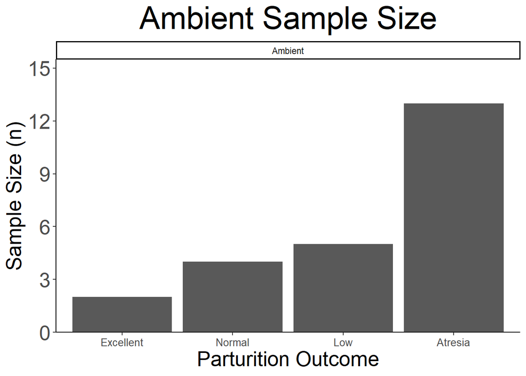

```r
# View Sample Distributions

# Sample Size barplot

# Ambient Samples
ambient_sample_size_barplot <- Ambient_Samples %>%
  group_by(Consensus_Brood_Condition, Ambient.Or.OAH) %>%
  summarise(n_size = n_distinct(Patient.ID_edited), .groups = "drop") %>%
  ggplot(aes(x = Consensus_Brood_Condition, y = n_size)) +
  geom_bar(stat = "identity") +
  facet_grid(~ Ambient.Or.OAH) +
  scale_y_continuous(expand = c(0, 0), limits = c(0, 15.5), breaks = c(0, 3, 6, 9, 12, 15)) +
  labs(title = "Ambient Sample Size",
        x = "Parturition Outcome",
        y = "Sample Size (n)") +
  theme_classic() +
  theme(panel.background = element_rect(fill = "white"),
        plot.background = element_rect(fill = "white"),
        legend.background = element_rect(fill = "white", color = "black"),
        title = element_text(size = 12),
        plot.title = element_text(size = 30, hjust = 0.5),
        axis.text.x = element_text(size = 10),
        axis.text.y = element_text(size = 20),
        axis.title.x = element_text(size = 20),
        axis.title.y = element_text(size = 20))
print(ambient_sample_size_barplot)
```

```r
ggsave(filename = "data-images/.png", plot = ambient_sample_size_barplot, device = "png")
ggsave(filename = "data-images/ambient_sample_size_barplot.pdf", plot = ambient_sample_size_barplot, device = "pdf")
```

## Paramater Analysis:

# pH

pH Summary Stats

```r
# pH
# Summary stats

# Ambient data
Ambient_Samples %>%
  group_by(Ambient.Or.OAH, Consensus_Brood_Condition) %>%
  summarize(count = n(),
            median = round(median(pH), 3),
            mean = round(mean(pH), 3),
            sd = round(sd(pH), 3),
            cv = round(sd(pH)/mean(pH), 3)) %>%
  ungroup()
```

```
## # A tibble: 4 × 7
##   Ambient.Or.OAH Consensus_Brood_Condition count median  mean    sd    cv
##   <chr>          <ord>                     <int>  <dbl> <dbl> <dbl> <dbl>
## 1 Ambient        Excellent                     2   7.44  7.44 0.013 0.002
## 2 Ambient        Normal                        4   7.48  7.45 0.087 0.012
## 3 Ambient        Low                           5   7.40  7.41 0.05  0.007
## 4 Ambient        Atresia                      13   7.37  7.38 0.1   0.014
```

pH Boxplot

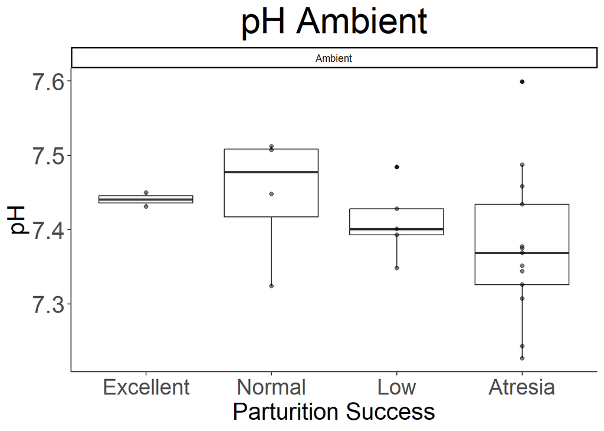

```r
# pH boxplot

# Ambient Samples
pH_ambient_boxplot <- ggplot(data = Ambient_Samples) +
  geom_boxplot(aes(x = Consensus_Brood_Condition, y = pH)) +
  geom_point(aes(x = Consensus_Brood_Condition, y = pH), alpha = 0.5, colour = "black") +
  labs(title = "pH Ambient", x = "Parturition Success", y = "pH") +
  facet_wrap(~ Ambient.Or.OAH) +
  theme_classic() +
  theme(panel.background = element_rect(fill = "white"),
        plot.background = element_rect(fill = "white"),
        legend.background = element_rect(fill = "white", color = "black"),
        title = element_text(size = 12),
        plot.title = element_text(size = 30, hjust = 0.5),
        axis.text.x = element_text(size = 18),
        axis.text.y = element_text(size = 20),
        axis.title.x = element_text(size = 20),
        axis.title.y = element_text(size = 20))

print(pH_ambient_boxplot)
```

```r
ggsave(filename = "data-images/pH_ambient_boxplot.pdf", plot = pH_ambient_boxplot, device = "pdf")
ggsave(filename = "data-images/pH_ambient_boxplot.png", plot = pH_ambient_boxplot, device = "png")
```

Test Outliers

```r
# pH
# Ambient

# Test outliers
```

pH Parametric Assessment Data Distribution

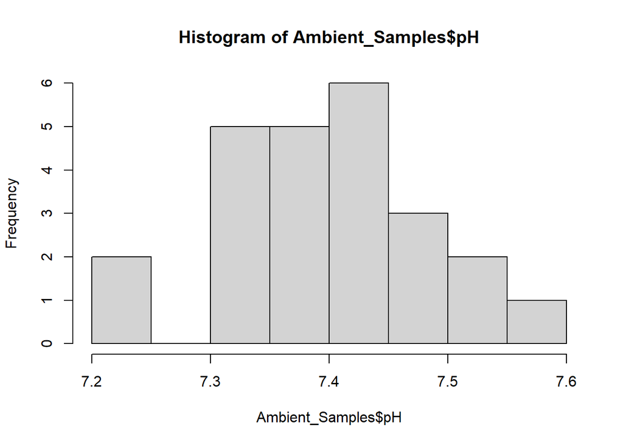

```r
# pH
# Parametric Assumptions

# Data Distribution

# Frequency Histogram
hist(Ambient_Samples$pH)
```

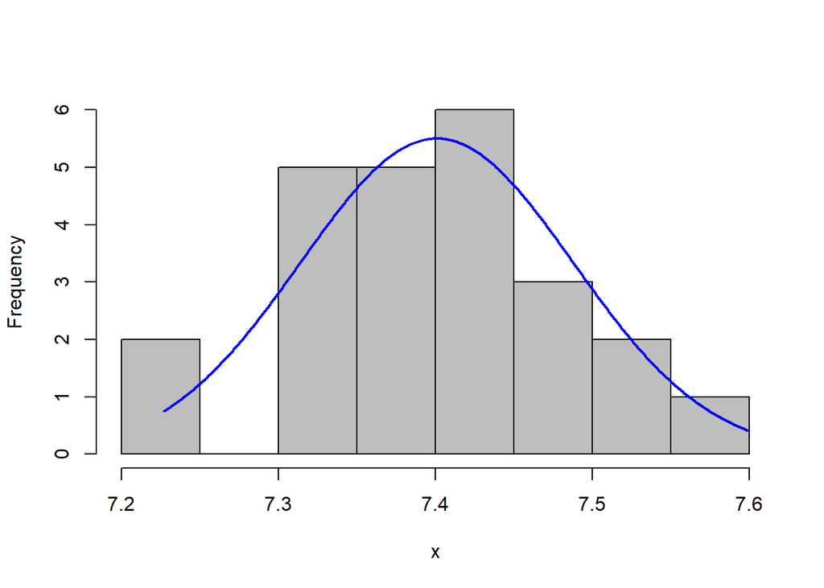

```r
plotNormalHistogram(Ambient_Samples$pH)
```

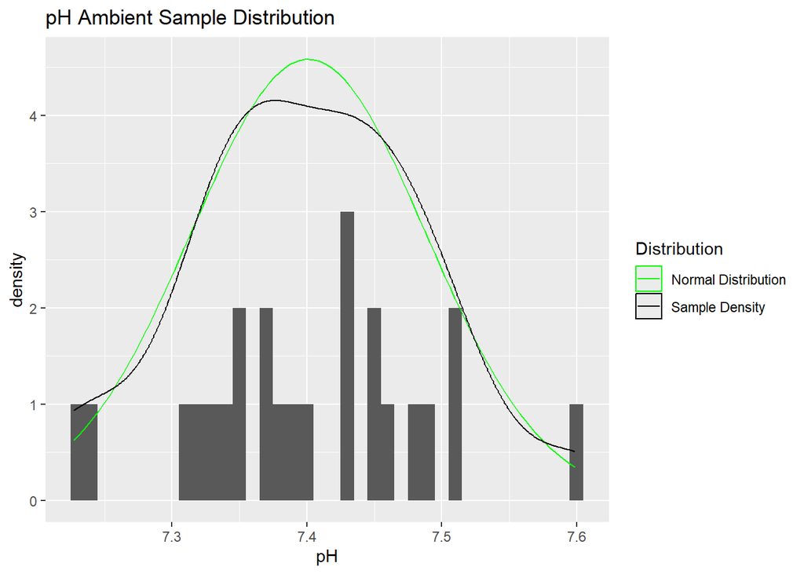

```r
# Density vs normality curve histograms
Ambient_Samples %>%
  ggplot(aes(x = pH)) +
  geom_histogram(binwidth = 0.01) +
  stat_function(fun = dnorm, args = c(mean = mean(Ambient_Samples$pH), sd = sd(Ambient_Samples$pH)), aes(col = "Normal Distribution"), show.legend = TRUE) +
  geom_density(aes(col = "Sample Density"), show.legend = TRUE) +
  labs(title = "pH Ambient Sample Distribution") +
  scale_color_manual("Distribution", values = c("Normal Distribution" = "green", "Sample Density" = "black"))
```

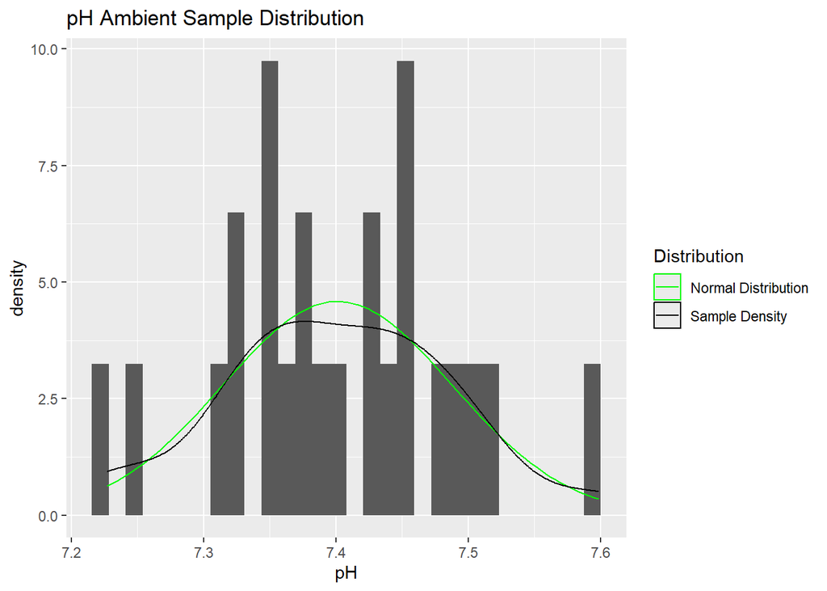

```r
# More accurate density curve?
Ambient_Samples %>%
  ggplot(aes(x = pH)) +
  geom_histogram(aes(x = pH, y = after_stat(density))) +
  stat_function(fun = dnorm, args = c(mean = mean(Ambient_Samples$pH), sd = sd(Ambient_Samples$pH)), aes(col = "Normal Distribution"), show.legend = TRUE) +
  geom_density(aes(col = "Sample Density"), show.legend = TRUE) +
  labs(title = "pH Ambient Sample Distribution") +
  scale_color_manual("Distribution", values = c("Normal Distribution" = "green", "Sample Density" = "black"))
```

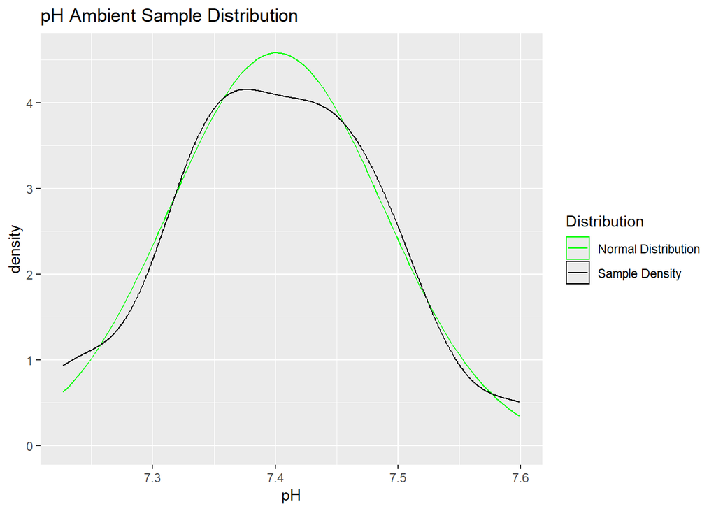

```r
# Density Plot with normal density
Ambient_Samples %>%
  ggplot(aes(x = pH)) +
  stat_function(fun = dnorm, args = c(mean = mean(Ambient_Samples$pH), sd = sd(Ambient_Samples$pH)), aes(col = "Normal Distribution"), show.legend = TRUE) +
  geom_density(aes(col = "Sample Density"), show.legend = TRUE) +
  labs(title = "pH Ambient Sample Distribution") +
  scale_color_manual("Distribution", values = c("Normal Distribution" = "green", "Sample Density" = "black"))
```

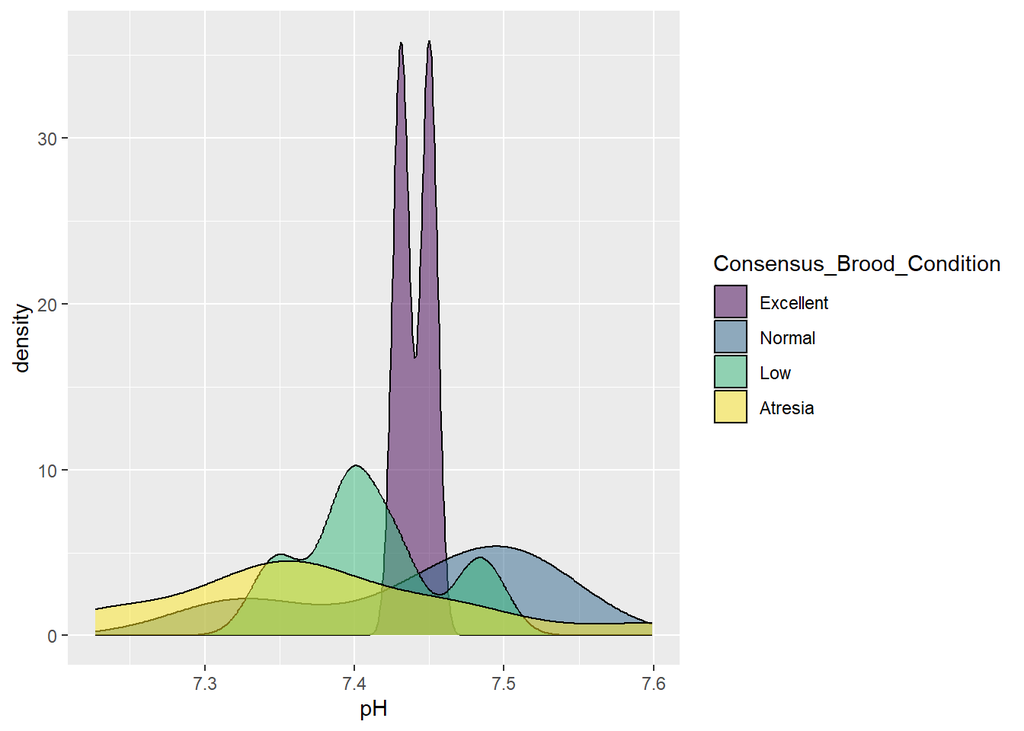

```r
# Density by brood condition
Ambient_Samples %>%
ggplot(aes(x = pH)) +
  geom_density(aes(x = pH, fill = Consensus_Brood_Condition), alpha = 0.5)
```

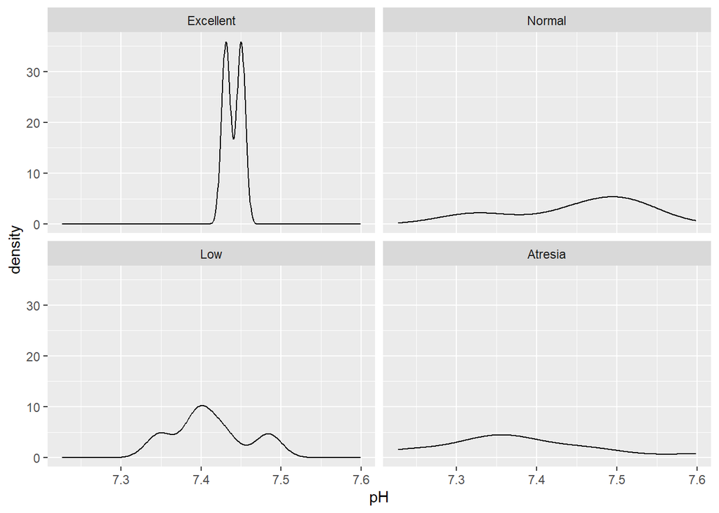

```r
ggplot(Ambient_Samples, aes(x = pH)) +
  geom_density(aes(x = pH)) +
  facet_wrap(~ Consensus_Brood_Condition)
```

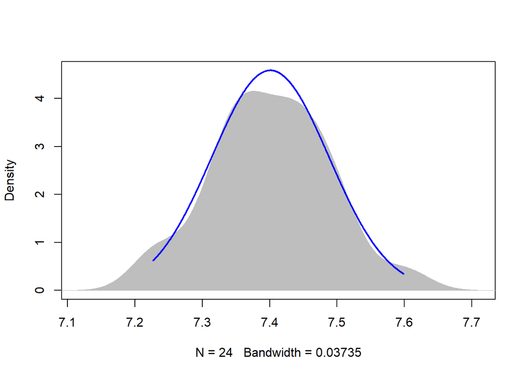

```r
plotNormalDensity(Ambient_Samples$pH)
```

Model Design:

[output not shown]

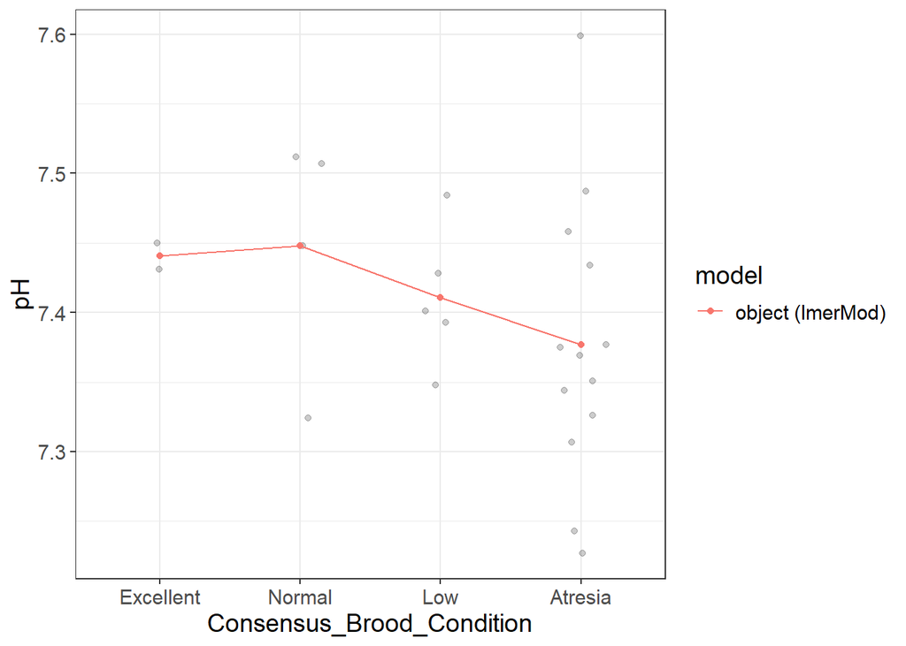

```r
# pH ambient data

# Install flexplot
# devtools::install_github("dustinfife/flexplot", ref="development")
require(flexplot)
pH_ambient_lmer <- lmer(pH ~ Consensus_Brood_Condition + (1|Consensus_Brood_Condition), data = Ambient_Samples)
visualize(pH_ambient_lmer, plot = "model", sample = 50)
```

Normality Residual QQplot

```r
# pH
# Parametric Assumptions:

# Assessing Normality

# Summary of model
summary(pH_ambient_lmer)
```

```
## Linear mixed model fit by REML. t-tests use Satterthwaite's method [
## lmerModLmerTest]
## Formula: pH ~ Consensus_Brood_Condition + (1 | Consensus_Brood_Condition)
##    Data: Ambient_Samples
##
## REML criterion at convergence: -32.9
##
## Scaled residuals:
##      Min       1Q   Median       3Q      Max
## -1.70520 -0.42367 -0.05345  0.65834  2.53239
##
## Random effects:
##  Groups                    Name        Variance Std.Dev.
##  Consensus_Brood_Condition (Intercept) 0.003066 0.05537
##  Residual                              0.007706 0.08779
## Number of obs: 24, groups:  Consensus_Brood_Condition, 4
##
## Fixed effects:
##                             Estimate Std. Error       df t value Pr(>|t|)
## (Intercept)                  7.41894    0.03551 20.00000 208.908   <2e-16 ***
## Consensus_Brood_Condition.L -0.05107    0.07239 20.00000  -0.705    0.489
## Consensus_Brood_Condition.Q -0.02068    0.07103 20.00000  -0.291    0.774
## Consensus_Brood_Condition.C  0.01052    0.06963 20.00000   0.151    0.881
## ---
## Signif. codes:  0 '***' 0.001 '**' 0.01 '*' 0.05 '.' 0.1 ' ' 1
##
## Correlation of Fixed Effects:
##             (Intr) C_B_C.L C_B_C.Q
## Cnsns_B_C.L -0.221
## Cnsns_B_C.Q  0.048 -0.204
## Cnsns_B_C.C -0.048  0.029  -0.100
## optimizer (nloptwrap) convergence code: 0 (OK)
##  Hessian is numerically singular: parameters are not uniquely determined
```

```r
# Suss residuals of model
pH_ambient_res_lmer <- residuals(pH_ambient_lmer)

# Shapiro test
shapiro.test(pH_ambient_res_lmer)
```

```
##
##  Shapiro-Wilk normality test
##
## data:  pH_ambient_res_lmer
## W = 0.95582, p-value = 0.3602
```

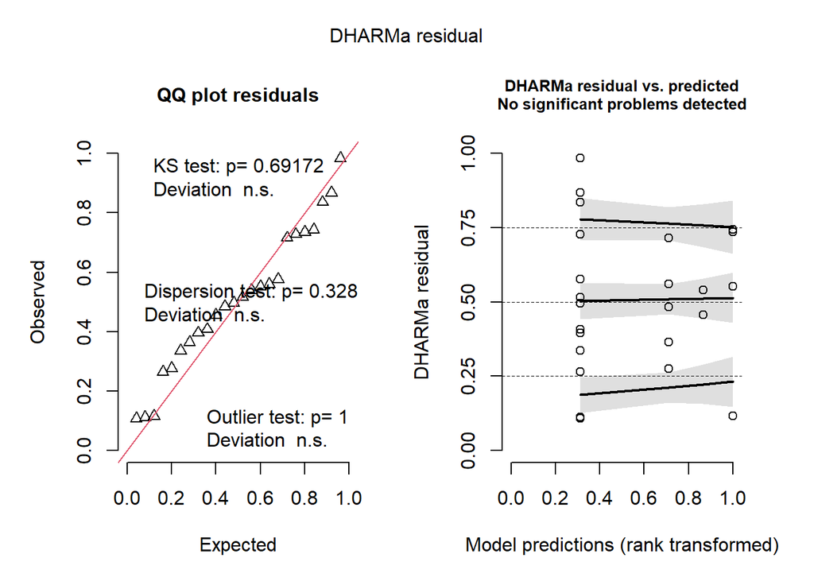

```r
# pH simulated residuals plot
pH_ambient_simres_plot <- simulateResiduals(fittedModel = pH_ambient_lmer)
plot(pH_ambient_simres_plot)
```

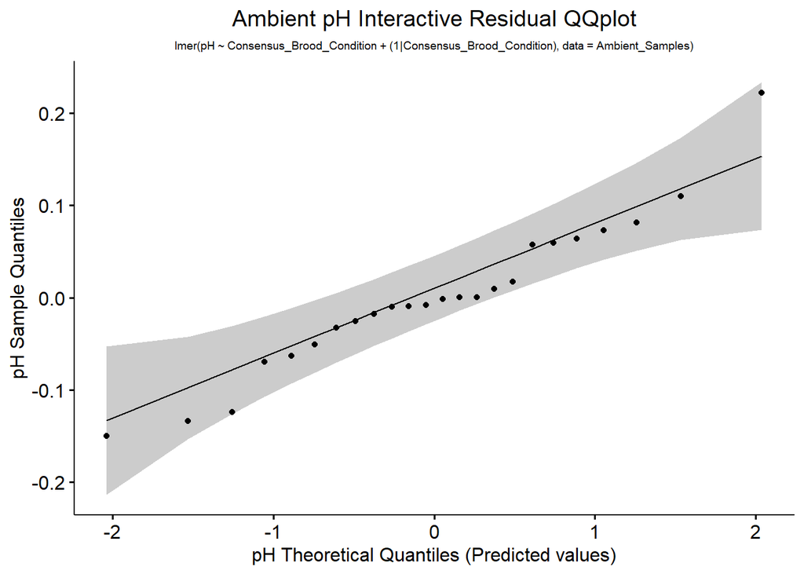

```r
# Qqplot of model
pH_ambient_res_qqplot <- ggqqplot(residuals(pH_ambient_lmer)) +
labs(title = "Ambient pH Interactive Residual QQplot",
     subtitle = "lmer(pH ~ Consensus_Brood_Condition + (1|Consensus_Brood_Condition), data = Ambient_Samples)",
                               x = "pH Theoretical Quantiles (Predicted values)",
                               y = "pH Sample Quantiles") +
  theme(plot.title = element_text(hjust = 0.5),
        plot.subtitle = element_text(hjust = 0.5, size = 7))
print(pH_ambient_res_qqplot)
```

```r
# ggsave(filename = "data-images/pH_ambient_res_int_qqplot.pdf", plot = pH_ambient_res_int_qqplot, device = "pdf")
# ggsave(filename = "data-images/pH_ambient_res_int_qqplot.png", plot = pH_ambient_res_int_qqplot, device = "png")
```

pH Parametric Assessment Testing Scedasticity:

```r
# pH

# Ambient samples

# test with lmer
bartlett.test(pH_ambient_res_lmer ~ Ambient_Samples$Consensus_Brood_Condition)
```

```
##
##  Bartlett test of homogeneity of variances
##
## data:  pH_ambient_res_lmer by Ambient_Samples$Consensus_Brood_Condition
## Bartlett's K-squared = 4.281, df = 3, p-value = 0.2327
```

```r
bartlett.test(pH ~ Consensus_Brood_Condition, Ambient_Samples)
```

```
##
##  Bartlett test of homogeneity of variances
##
## data:  pH by Consensus_Brood_Condition
## Bartlett's K-squared = 4.281, df = 3, p-value = 0.2327
```

```r
# leveneTest(pH ~ Consensus_Brood_Condition, Ambient_Samples)
```

pH Parametric Assumptions Assessment:

Warning: Check after assessing outliers

- Ambient Data normally distributed?
- Ambient Data equal variance across factors?

# pH Stat Tests

```r
# pH
# Ambient ANOVA Test

# Testing for differences in ambient parturition success metrics
# One-way ANOVA (parametric) or Kruskal-Wallis test (nonparametric)

pH_aov_ambient <- aov(pH ~ Consensus_Brood_Condition, data = Ambient_Samples)
summary(pH_aov_ambient)
```

```
##                           Df  Sum Sq  Mean Sq F value Pr(>F)
## Consensus_Brood_Condition  3 0.02002 0.006675   0.866  0.475
## Residuals                 20 0.15413 0.007706
```

```r
# If significant, Post Hoc Test:
# - Tukey's HSD (parametric, normality & equal variance across groups)
# - Dunn's test (non-parametric, after Kruskal-Wallis test)

TukeyHSD(pH_aov_ambient)
```

```
##   Tukey multiple comparisons of means
##     95% family-wise confidence level
##
## Fit: aov(formula = pH ~ Consensus_Brood_Condition, data = Ambient_Samples)
##
## $Consensus_Brood_Condition
##                          diff        lwr        upr     p adj
## Normal-Excellent   0.00725000 -0.2055383 0.22003829 0.9996783
## Low-Excellent     -0.02970000 -0.2352730 0.17587302 0.9770314
## Atresia-Excellent -0.06380769 -0.2504354 0.12281999 0.7748296
## Low-Normal        -0.03695000 -0.2017751 0.12787510 0.9220092
## Atresia-Normal    -0.07105769 -0.2115459 0.06943052 0.5045821
## Atresia-Low       -0.03410769 -0.1634071 0.09519176 0.8804799
```

pH Ambient Results

Which brood condition significantly different (if any)?

# Hct : Hematocrit

Hematocrit Summary Stats

```r
# hct
# Summary stats

# Ambient data
Ambient_Samples %>%
  group_by(Ambient.Or.OAH, Consensus_Brood_Condition) %>%
  summarize(count = n(),
            median = round(median(Hct....), 3),
            mean = round(mean(Hct....), 3),
            sd = round(sd(Hct....), 3),
            cv = round(sd(Hct....)/mean(Hct....), 3)) %>%
  ungroup()
```

```
## # A tibble: 4 × 7
##   Ambient.Or.OAH Consensus_Brood_Condition count median  mean    sd    cv
##   <chr>          <ord>                     <int>  <dbl> <dbl> <dbl> <dbl>
## 1 Ambient        Excellent                     2   16.4  16.4  2.48 0.15
## 2 Ambient        Normal                        4   13.8  15.4  4.33 0.281
## 3 Ambient        Low                           5   13.3  12.7  2.83 0.223
## 4 Ambient        Atresia                      13   17.3  18.2  2.33 0.128
```

Hematocrit Boxplot

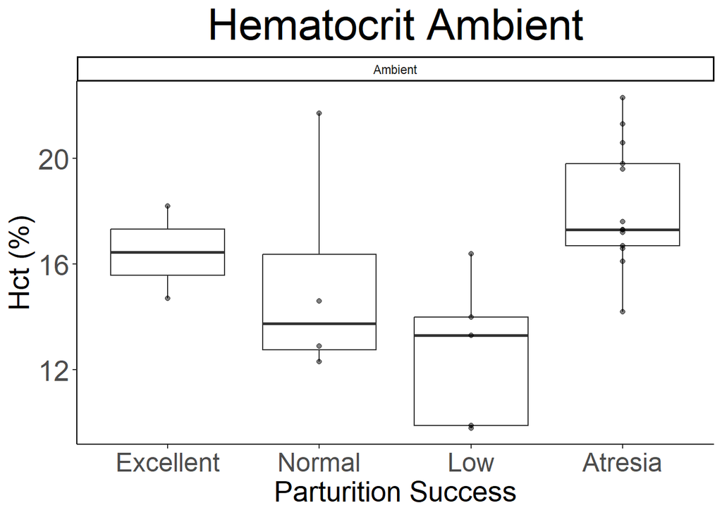

```r
# hct boxplot

# Ambient Samples
hct_ambient_boxplot <- ggplot(data = Ambient_Samples) +
  geom_boxplot(aes(x = Consensus_Brood_Condition, y = Hct....)) +
  geom_point(aes(x = Consensus_Brood_Condition, y = Hct....), alpha = 0.5, colour = "black") +
  labs(title = "Hematocrit Ambient", x = "Parturition Success", y = "Hct (%)") +
  facet_wrap(~ Ambient.Or.OAH) +
  theme_classic() +
  theme(panel.background = element_rect(fill = "white"),
        plot.background = element_rect(fill = "white"),
        legend.background = element_rect(fill = "white", color = "black"),
        title = element_text(size = 12),
        plot.title = element_text(size = 30, hjust = 0.5),
        axis.text.x = element_text(size = 18),
        axis.text.y = element_text(size = 20),
        axis.title.x = element_text(size = 20),
        axis.title.y = element_text(size = 20))

print(hct_ambient_boxplot)
```

```r
ggsave(filename = "data-images/hct_ambient_boxplot.pdf", plot = hct_ambient_boxplot, device = "pdf")
ggsave(filename = "data-images/hct_ambient_boxplot.png", plot = hct_ambient_boxplot, device = "png")
```

Test Outliers

```r
# hct
# Ambient

# Test outliers
```

Hct Parametric Assessment Data Distribution

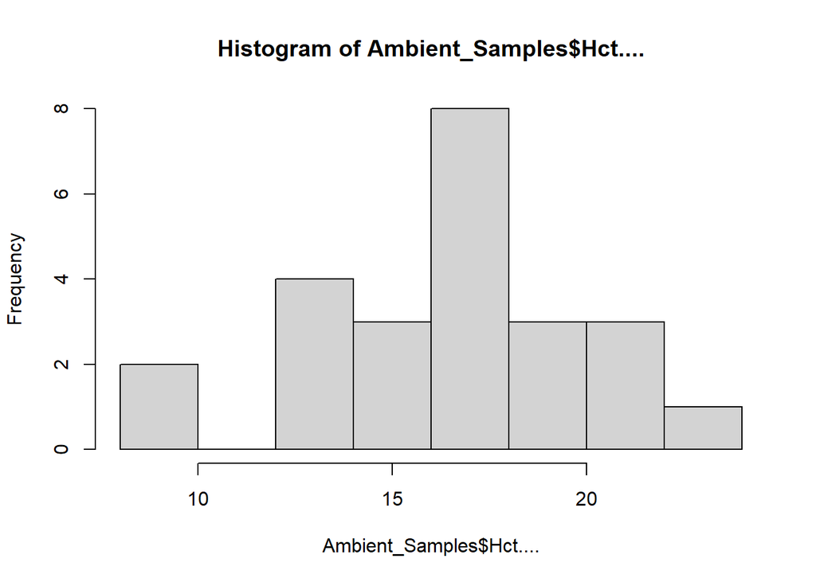

```r
# Hct
# Parametric Assumptions

# Data Distribution

# Frequency Histogram
hct_ambient_hist <- hist(Ambient_Samples$Hct....)
```

```r
print(hct_ambient_hist)
```

```
## $breaks
## [1]  8 10 12 14 16 18 20 22 24
##
## $counts
## [1] 2 0 4 3 8 3 3 1
##
## $density
## [1] 0.04166667 0.00000000 0.08333333 0.06250000 0.16666667 0.06250000 0.06250000
## [8] 0.02083333
##
## $mids
## [1]  9 11 13 15 17 19 21 23
##
## $xname
## [1] "Ambient_Samples$Hct...."
##
## $equidist
## [1] TRUE
##
## attr(,"class")
## [1] "histogram"
```

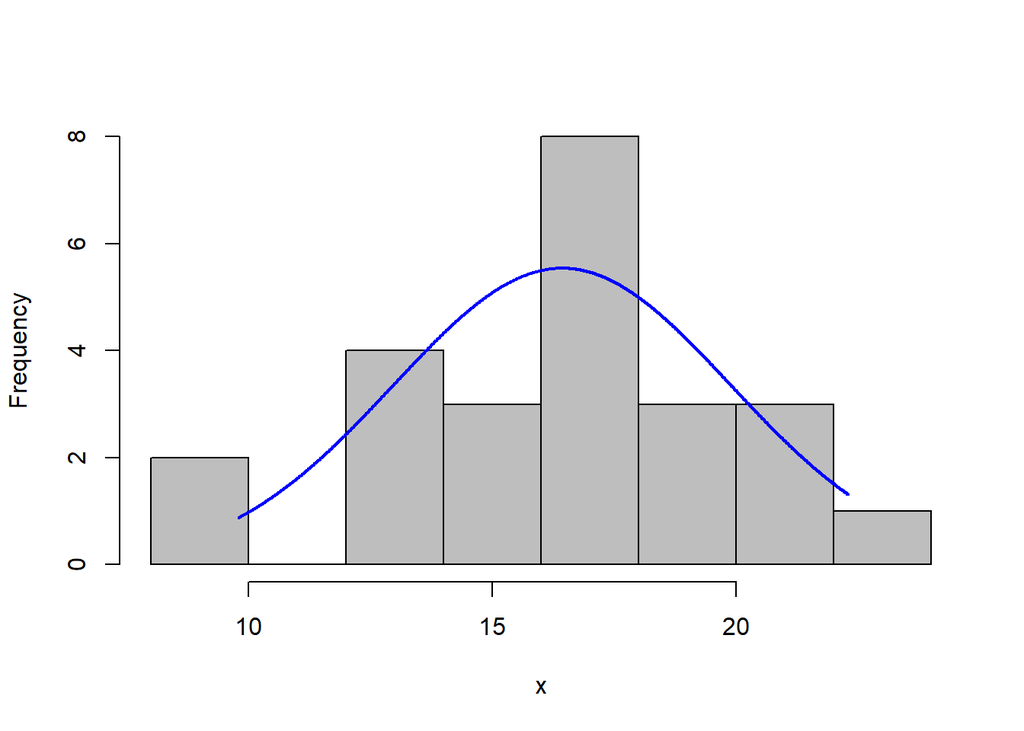

```r
plotNormalHistogram(Ambient_Samples$Hct....)
```

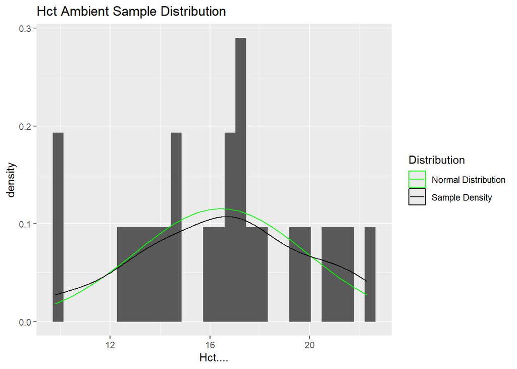

```r
# Density vs normality curve histograms
Ambient_Samples %>%
  ggplot(aes(x = Hct....)) +
  geom_histogram(aes(x = Hct...., y = after_stat(density))) +
  stat_function(fun = dnorm, args = c(mean = mean(Ambient_Samples$Hct....), sd = sd(Ambient_Samples$Hct....)), aes(col = "Normal Distribution"), show.legend = TRUE) +
  geom_density(aes(col = "Sample Density"), show.legend = TRUE) +
  labs(title = "Hct Ambient Sample Distribution") +
  scale_color_manual("Distribution", values = c("Normal Distribution" = "green", "Sample Density" = "black"))
```

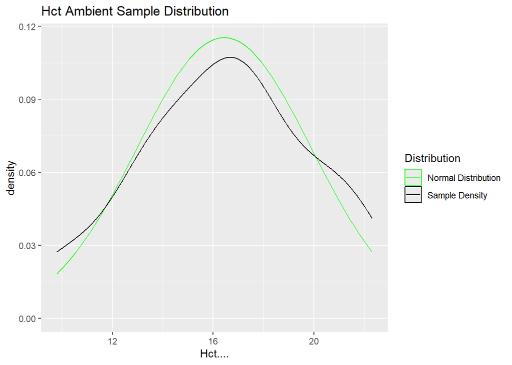

```r
# Density Plot with normal density
Ambient_Samples %>%
  ggplot(aes(x = Hct....)) +
  stat_function(fun = dnorm, args = c(mean = mean(Ambient_Samples$Hct....), sd = sd(Ambient_Samples$Hct....)), aes(col = "Normal Distribution"), show.legend = TRUE) +
  geom_density(aes(col = "Sample Density"), show.legend = TRUE) +
  labs(title = "Hct Ambient Sample Distribution") +
  scale_color_manual("Distribution", values = c("Normal Distribution" = "green", "Sample Density" = "black"))
```

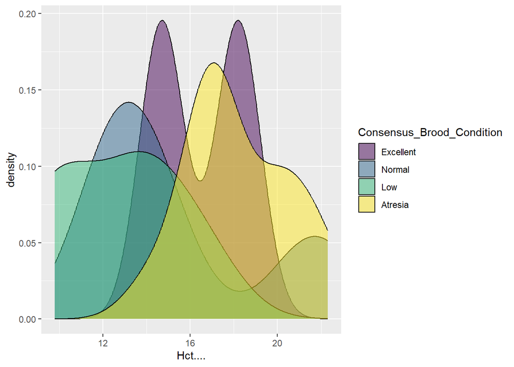

```r
# Density by brood condition
Ambient_Samples %>%
ggplot(aes(x = Hct....)) +
  geom_density(aes(x = Hct...., fill = Consensus_Brood_Condition), alpha = 0.5)
```

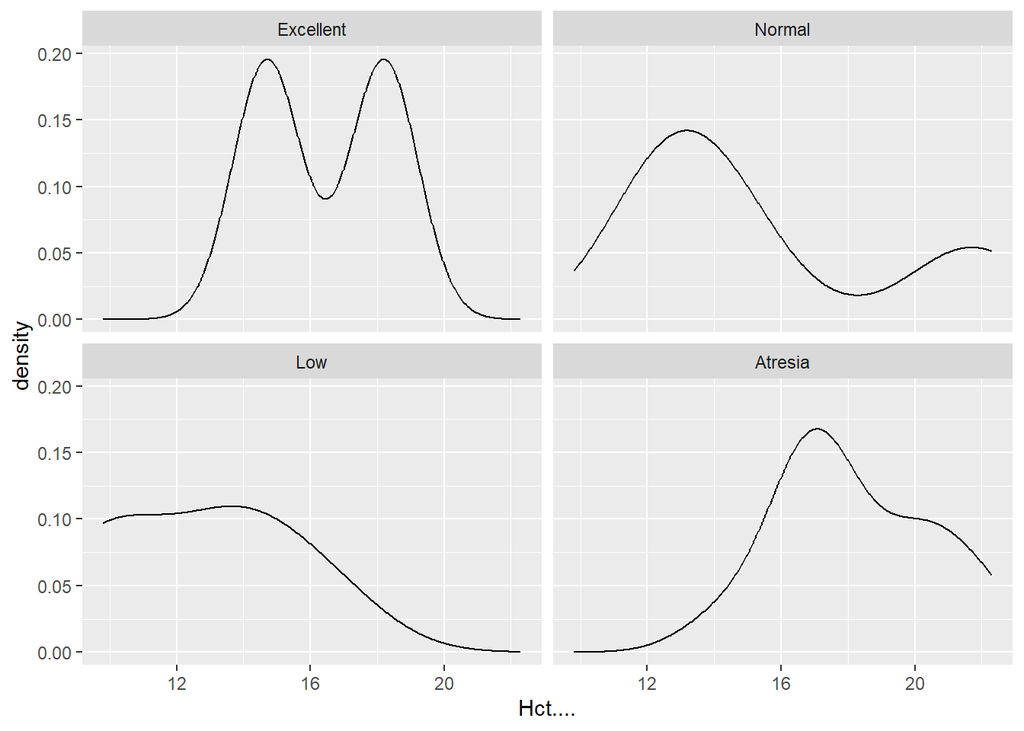

```r
ggplot(Ambient_Samples, aes(x = Hct....)) +
  geom_density(aes(x = Hct....)) +
  facet_wrap(~ Consensus_Brood_Condition)
```

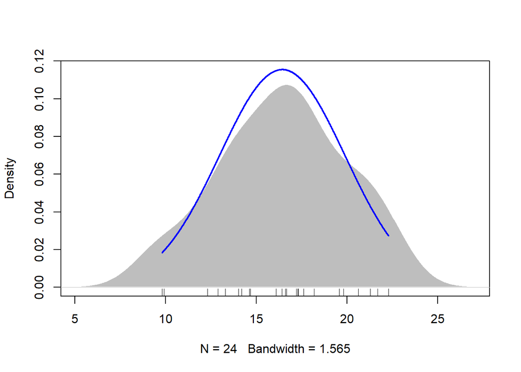

```
## numeric(0)
```

```r
plotNormalDensity(Ambient_Samples$Hct....) +
  rug(jitter(Ambient_Samples$Hct....))
```

Model Design:

```r
# hct ambient data

hct_ambient_lmer <- lmer(Hct.... ~ Consensus_Brood_Condition + (1|Consensus_Brood_Condition), data = Ambient_Samples)
```

[output not shown]

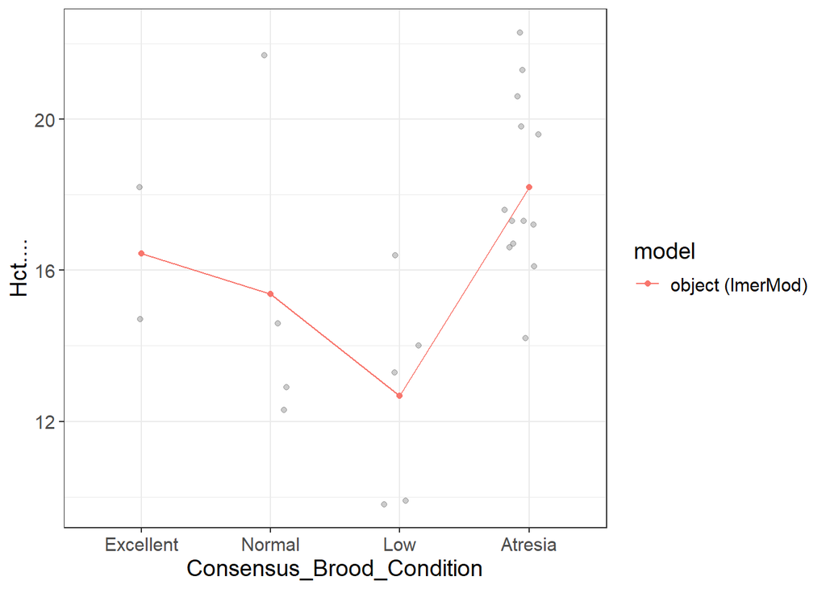

```r
visualize(hct_ambient_lmer, plot = "model", sample = 50)
```

Normality Residual QQplot

```r
# hct
# Parametric Assumptions:

# Assessing Normality

# Summary of model
summary(hct_ambient_lmer)
```

```
## Linear mixed model fit by REML. t-tests use Satterthwaite's method [
## lmerModLmerTest]
## Formula: Hct.... ~ Consensus_Brood_Condition + (1 | Consensus_Brood_Condition)
##    Data: Ambient_Samples
##
## REML criterion at convergence: 105.9
##
## Scaled residuals:
##     Min      1Q  Median      3Q     Max
## -1.4178 -0.6513 -0.2968  0.5804  2.2418
##
## Random effects:
##  Groups                    Name        Variance Std.Dev.
##  Consensus_Brood_Condition (Intercept) 5.775    2.403
##  Residual                              7.960    2.821
## Number of obs: 24, groups:  Consensus_Brood_Condition, 4
##
## Fixed effects:
##                             Estimate Std. Error      df t value Pr(>|t|)
## (Intercept)                  15.6762     1.3981 20.0000  11.213 4.46e-10 ***
## Consensus_Brood_Condition.L   0.5713     2.8320 20.0000   0.202    0.842
## Consensus_Brood_Condition.Q   3.2975     2.7961 20.0000   1.179    0.252
## Consensus_Brood_Condition.C   2.1992     2.7597 20.0000   0.797    0.435
## ---
## Signif. codes:  0 '***' 0.001 '**' 0.01 '*' 0.05 '.' 0.1 ' ' 1
##
## Correlation of Fixed Effects:
##             (Intr) C_B_C.L C_B_C.Q
## Cnsns_B_C.L -0.148
## Cnsns_B_C.Q  0.032 -0.137
## Cnsns_B_C.C -0.031  0.019  -0.066
## optimizer (nloptwrap) convergence code: 0 (OK)
## unable to evaluate scaled gradient
##  Hessian is numerically singular: parameters are not uniquely determined
```

```r
# Suss residuals of model
hct_ambient_res_lmer <- residuals(hct_ambient_lmer)

# Shapiro test
shapiro.test(hct_ambient_res_lmer)
```

```
##
##  Shapiro-Wilk normality test
##
## data:  hct_ambient_res_lmer
## W = 0.95061, p-value = 0.2793
```

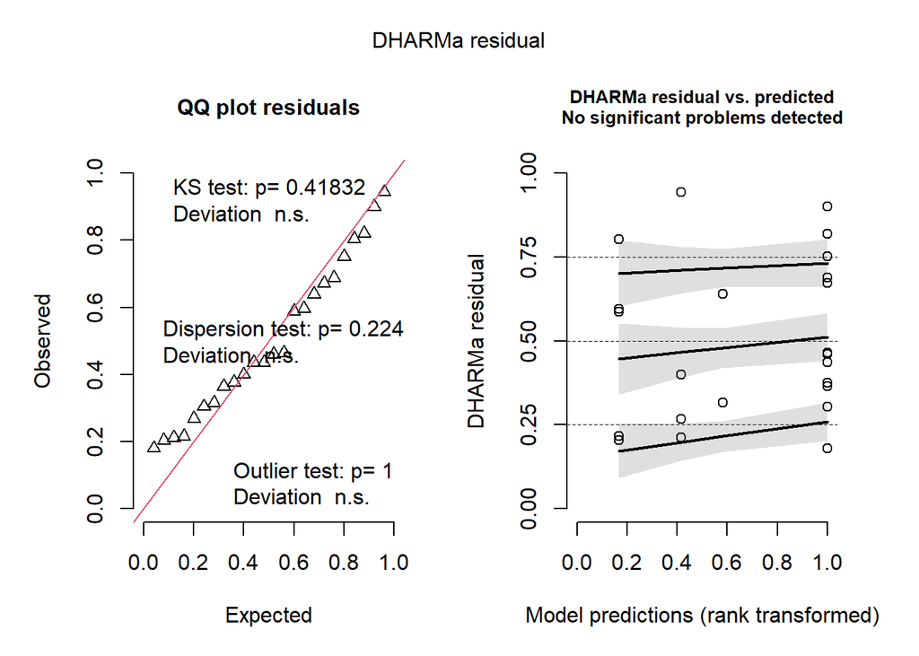

```r
# hct simulated residuals plot
hct_ambient_simres_plot <- simulateResiduals(fittedModel = hct_ambient_lmer)
plot(hct_ambient_simres_plot)
```

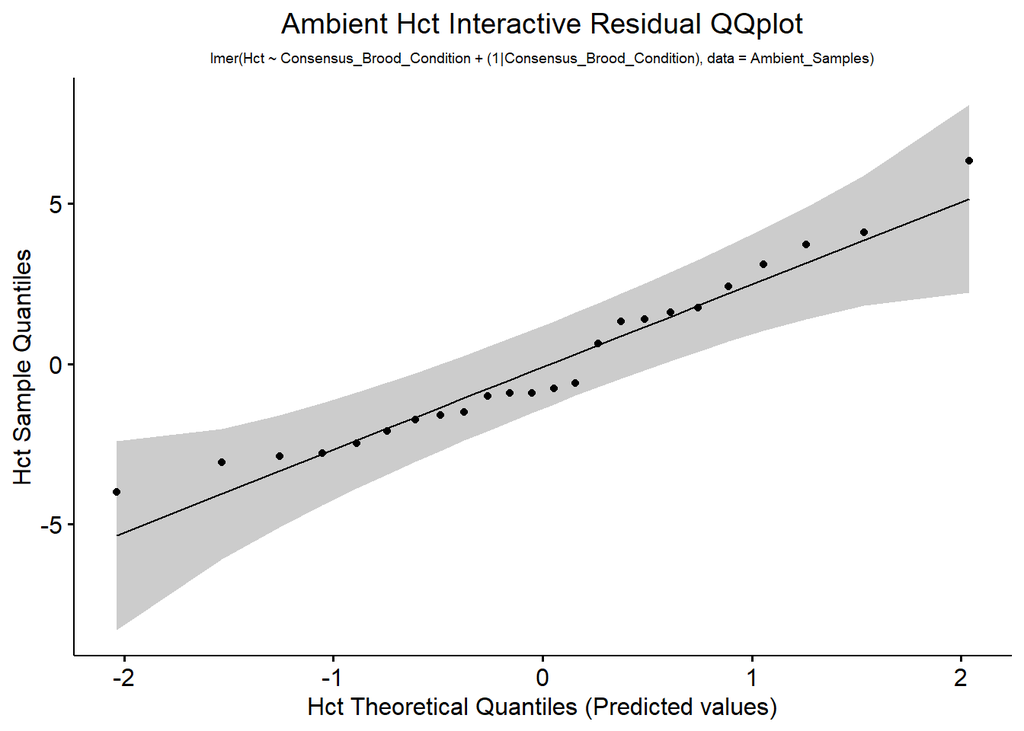

```r
# Qqplot of model
hct_ambient_res_qqplot <- ggqqplot(residuals(hct_ambient_lmer)) +
labs(title = "Ambient Hct Interactive Residual QQplot",
     subtitle = "lmer(Hct ~ Consensus_Brood_Condition + (1|Consensus_Brood_Condition), data = Ambient_Samples)",
                               x = "Hct Theoretical Quantiles (Predicted values)",
                               y = "Hct Sample Quantiles") +
  theme(plot.title = element_text(hjust = 0.5),
        plot.subtitle = element_text(hjust = 0.5, size = 7))
print(hct_ambient_res_qqplot)
```

```r
# ggsave(filename = "data-images/hct_ambient_res_int_qqplot.pdf", plot = hct_ambient_res_int_qqplot, device = "pdf")
# ggsave(filename = "data-images/hct_ambient_res_int_qqplot.png", plot = hct_ambient_res_int_qqplot, device = "png")
```

hematocrit Parametric Assessment Testing Scedasticity:

```r
# hct

# Ambient samples

# test with lmer
bartlett.test(hct_ambient_res_lmer ~ Ambient_Samples$Consensus_Brood_Condition)
```

```
##
##  Bartlett test of homogeneity of variances
##
## data:  hct_ambient_res_lmer by Ambient_Samples$Consensus_Brood_Condition
## Bartlett's K-squared = 1.962, df = 3, p-value = 0.5803
```

```r
bartlett.test(Hct.... ~ Consensus_Brood_Condition, Ambient_Samples)
```

```
##
##  Bartlett test of homogeneity of variances
##
## data:  Hct.... by Consensus_Brood_Condition
## Bartlett's K-squared = 1.962, df = 3, p-value = 0.5803
```

```r
# leveneTest(hct ~ Consensus_Brood_Condition, Ambient_Samples)
```

Hct Parametric Assumptions Assessment:

Warning: Check after assessing outliers

- Ambient Data normally distributed?
- Ambient Data equal variance across factors?

# Hct Stat Tests

```r
# hct
# Ambient ANOVA Test

# Testing for differences in ambient parturition success metrics
# One-way ANOVA (parametric) or Kruskal-Wallis test (nonparametric)

hct_aov_ambient <- aov(Hct.... ~ Consensus_Brood_Condition, data = Ambient_Samples)
summary(hct_aov_ambient)
```

```
##                           Df Sum Sq Mean Sq F value Pr(>F)
## Consensus_Brood_Condition  3  115.5   38.50   4.836 0.0109 *
## Residuals                 20  159.2    7.96
## ---
## Signif. codes:  0 '***' 0.001 '**' 0.01 '*' 0.05 '.' 0.1 ' ' 1
```

```r
# If significant, Post Hoc Test:
# - Tukey's HSD (parametric, normality & equal variance across groups)
# - Dunn's test (non-parametric, after Kruskal-Wallis test)

TukeyHSD(hct_aov_ambient)
```

```
##   Tukey multiple comparisons of means
##     95% family-wise confidence level
##
## Fit: aov(formula = Hct.... ~ Consensus_Brood_Condition, data = Ambient_Samples)
##
## $Consensus_Brood_Condition
##                     diff        lwr      upr     p adj
## Normal-Excellent  -1.075  -7.913815 5.763815 0.9707884
## Low-Excellent     -3.770 -10.376923 2.836923 0.4025798
## Atresia-Excellent  1.750  -4.248037 7.748037 0.8459123
## Low-Normal        -2.695  -7.992323 2.602323 0.4997382
## Atresia-Normal     2.825  -1.690158 7.340158 0.3249603
## Atresia-Low        5.520   1.364438 9.675562 0.0068411
```

Hct Ambient Results

Which brood condition significantly different (if any)?

# Glucose

Glucose Summary Stats

```r
# glucose
# Summary stats

# Ambient data
Ambient_Samples %>%
  group_by(Ambient.Or.OAH, Consensus_Brood_Condition) %>%
  summarize(count = n(),
            median = round(median(Glu..mmol.L.), 3),
            mean = round(mean(Glu..mmol.L.), 3),
            sd = round(sd(Glu..mmol.L.), 3),
            cv = round(sd(Glu..mmol.L.)/mean(Glu..mmol.L.), 3)) %>%
  ungroup()
```

```
## # A tibble: 4 × 7
##   Ambient.Or.OAH Consensus_Brood_Condition count median  mean    sd    cv
##   <chr>          <ord>                     <int>  <dbl> <dbl> <dbl> <dbl>
## 1 Ambient        Excellent                     2   1.55  1.55 0.354 0.228
## 2 Ambient        Normal                        4   1.55  1.58 0.275 0.175
## 3 Ambient        Low                           5   0.9   1.24 0.899 0.725
## 4 Ambient        Atresia                      13   2     2.1  0.698 0.332
```

Glucose Boxplot

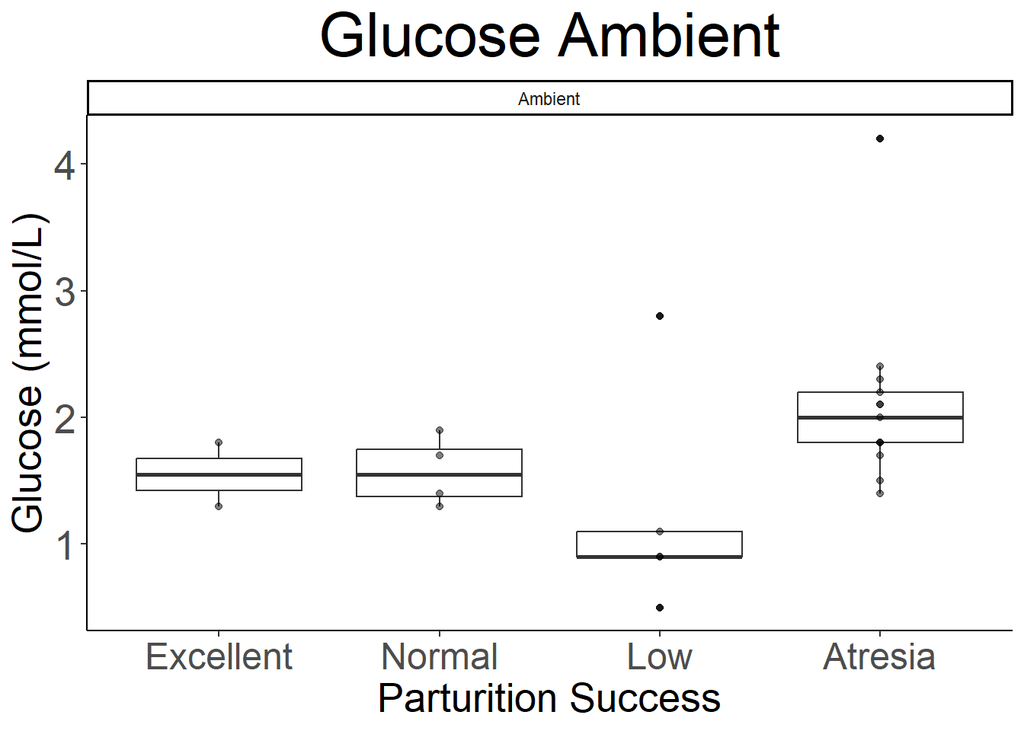

```r
# glucose boxplot

# Ambient Samples
glucose_ambient_boxplot <- ggplot(data = Ambient_Samples) +
  geom_boxplot(aes(x = Consensus_Brood_Condition, y = Glu..mmol.L.)) +
  geom_point(aes(x = Consensus_Brood_Condition, y = Glu..mmol.L.), alpha = 0.5, colour = "black") +
  labs(title = "Glucose Ambient", x = "Parturition Success", y = "Glucose (mmol/L)") +
  facet_wrap(~ Ambient.Or.OAH) +
  theme_classic() +
  theme(panel.background = element_rect(fill = "white"),
        plot.background = element_rect(fill = "white"),
        legend.background = element_rect(fill = "white", color = "black"),
        title = element_text(size = 12),
        plot.title = element_text(size = 30, hjust = 0.5),
        axis.text.x = element_text(size = 18),
        axis.text.y = element_text(size = 20),
        axis.title.x = element_text(size = 20),
        axis.title.y = element_text(size = 20))

print(glucose_ambient_boxplot)
```

```r
ggsave(filename = "data-images/glucose_ambient_boxplot.pdf", plot = glucose_ambient_boxplot, device = "pdf")
ggsave(filename = "data-images/glucose_ambient_boxplot.png", plot = glucose_ambient_boxplot, device = "png")
```

Test Outliers

```r
# glucose
# Ambient

# Test outliers
```

Glucose Parametric Assessment Data Distribution

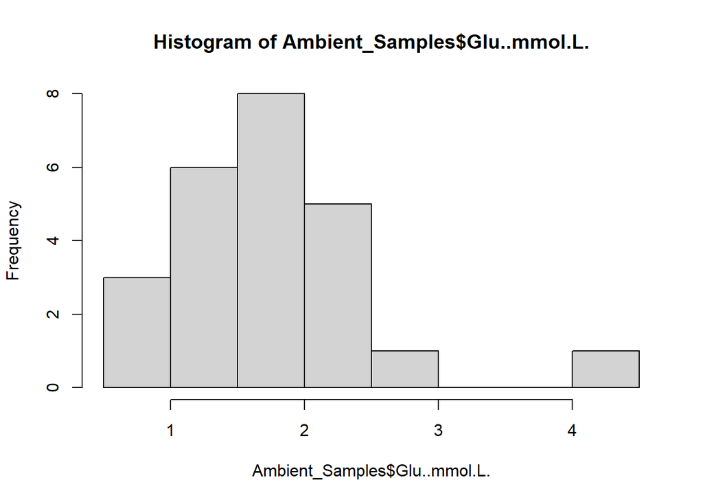

```r
# glucose
# Parametric Assumptions

# Data Distribution

# Frequency Histogram
hist(Ambient_Samples$Glu..mmol.L.)
```

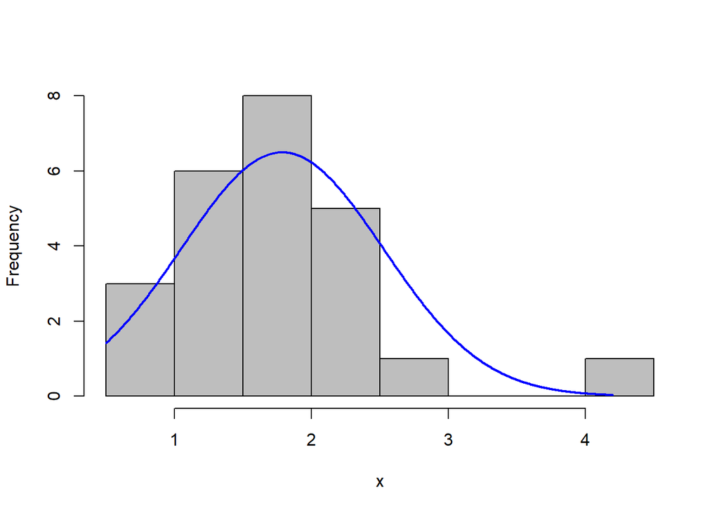

```r
plotNormalHistogram(Ambient_Samples$Glu..mmol.L.)
```

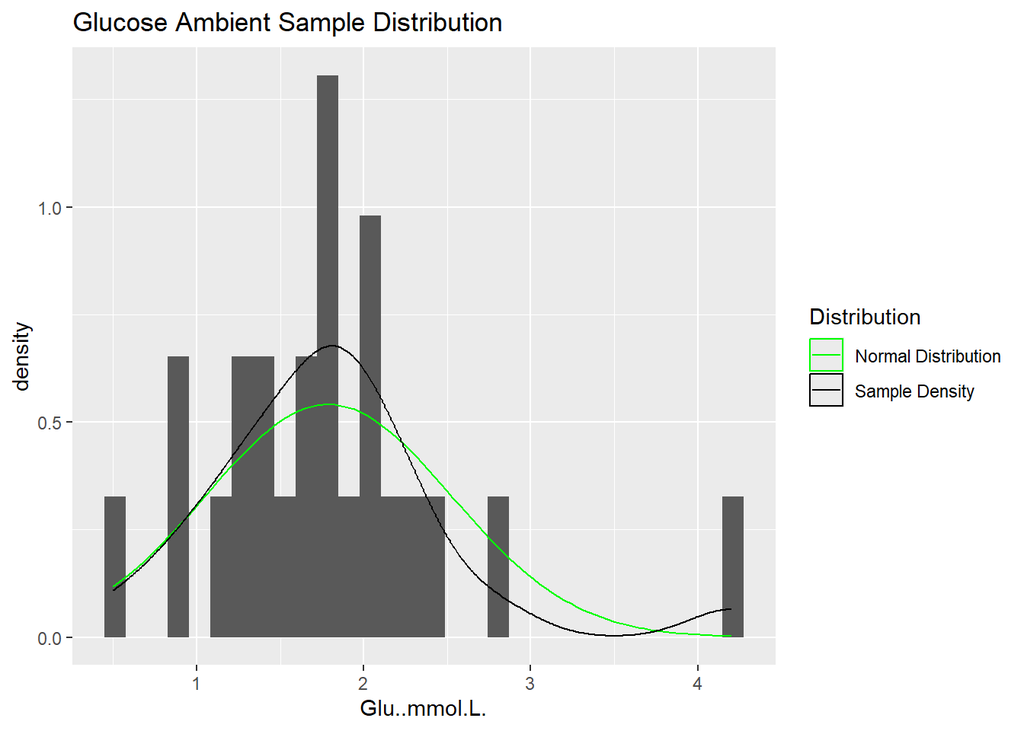

```r
# More accurate density curve
Ambient_Samples %>%
  ggplot(aes(x = Glu..mmol.L.)) +
  geom_histogram(aes(x = Glu..mmol.L., y = after_stat(density))) +
  stat_function(fun = dnorm, args = c(mean = mean(Ambient_Samples$Glu..mmol.L.), sd = sd(Ambient_Samples$Glu..mmol.L.)), aes(col = "Normal Distribution"), show.legend = TRUE) +
  geom_density(aes(col = "Sample Density"), show.legend = TRUE) +
  labs(title = "Glucose Ambient Sample Distribution") +
  scale_color_manual("Distribution", values = c("Normal Distribution" = "green", "Sample Density" = "black"))
```

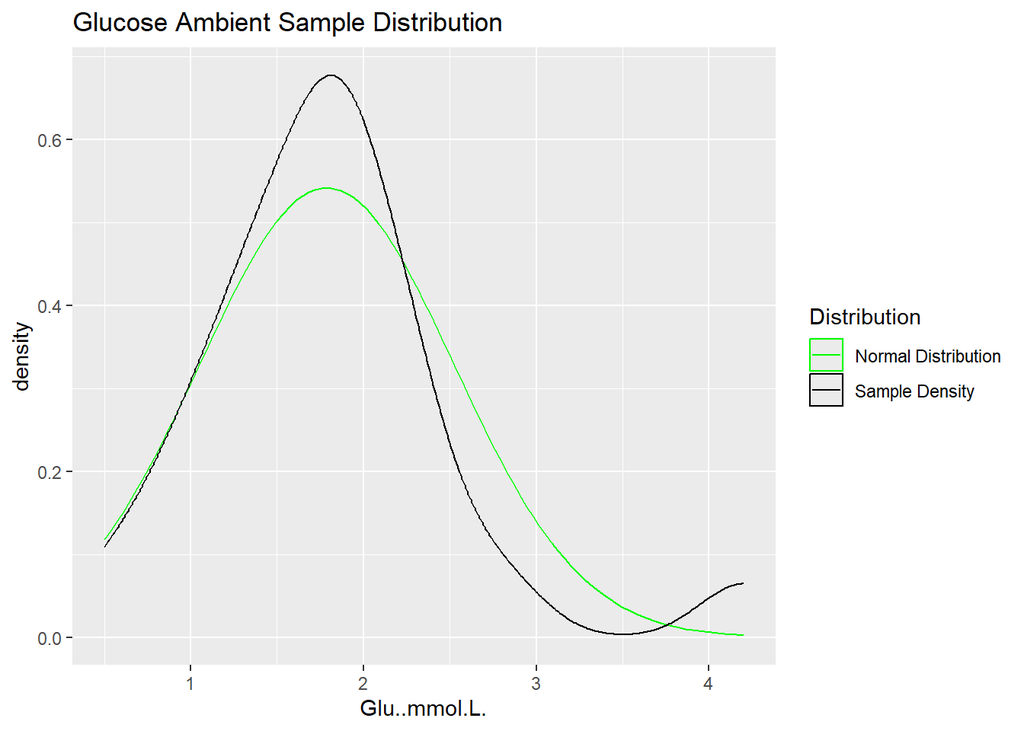

```r
# Density Plot with normal density
Ambient_Samples %>%
  ggplot(aes(x = Glu..mmol.L.)) +
  stat_function(fun = dnorm, args = c(mean = mean(Ambient_Samples$Glu..mmol.L.), sd = sd(Ambient_Samples$Glu..mmol.L.)), aes(col = "Normal Distribution"), show.legend = TRUE) +
  geom_density(aes(col = "Sample Density"), show.legend = TRUE) +
  labs(title = "Glucose Ambient Sample Distribution") +
  scale_color_manual("Distribution", values = c("Normal Distribution" = "green", "Sample Density" = "black"))
```

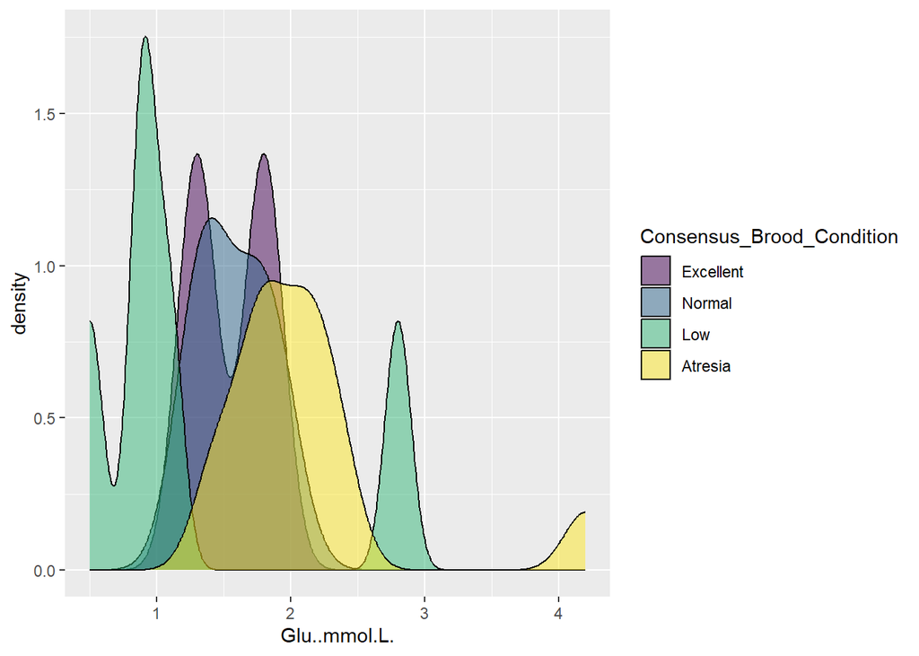

```r
# Density by brood condition
Ambient_Samples %>%
ggplot(aes(x = Glu..mmol.L.)) +
  geom_density(aes(x = Glu..mmol.L., fill = Consensus_Brood_Condition), alpha = 0.5)
```